# campaign_ad_data_analysis

Esther Kamau

January 12, 2021

```r
knitr::opts_chunk$set(fig.width=12, fig.height=8, fig.path='Figs/',
                      echo=TRUE, warning=TRUE, message=TRUE)
```

##RMarkdown

# R PROGRAMMING BASICS: EXPLOLATORY DATA ANALYSIS

# 1.Defining the problem

The research problem in this case is to find out individuals that are likely to click on a blog advert based on their characteristics which include; Age Daily Time spent on site Area of residence Internet Usage Gender Country of residence

# 2.Metric of Success

The metric success of this project is to identify clients likely to click on the ad after performing intense data analysis(EDA).

# 3.Data Relevance

# 4.Understanding the Context

A Kenyan entrepreneur has created an online cryptography course and would want to advertise it on her blog. She currently targets audiences originating from various countries. In the past, she ran ads to advertise a related course on the same blog and collected data in the process. She would now like to employ your services as a Data Science Consultant to help her identify which individuals are most likely to click on her ads.To achieve this we will perform exploratory data analysis on a dataset using R programming language.

# 5.Experimental Design

- .Data Loading
- .Data cleaning for missing values and outliers
- .Exploratory Data Analysis
- .Conclusion-Detecting the trend in behavior.

```r
# To Save the commands used during the session
#savehistory(file="mylog.Rhistory")
```

# 6.Reading the Data

```r
# Install the following packages:
#install.packages("foreign")
#library(foreign)
#install.packages("car")
#install.packages("Hmisc")
#install.packages("reshape")
```

```r
advertising <- read.csv('http://bit.ly/IPAdvertisingData',header = TRUE,
                 sep = ",",fileEncoding = "UTF-8-BOM")
```

# 7.Checking the Data

```r
# Previewing top of th dataset
#first 6 rows
# ---
head(advertising)
```

```
##   Daily.Time.Spent.on.Site Age Area.Income Daily.Internet.Usage
## 1                    68.95  35    61833.90               256.09
## 2                    80.23  31    68441.85               193.77
## 3                    69.47  26    59785.94               236.50
## 4                    74.15  29    54806.18               245.89
## 5                    68.37  35    73889.99               225.58
## 6                    59.99  23    59761.56               226.74
##                           Ad.Topic.Line           City Male    Country
## 1    Cloned 5thgeneration orchestration    Wrightburgh    0    Tunisia
## 2    Monitored national standardization      West Jodi    1      Nauru
## 3      Organic bottom-line service-desk       Davidton    0 San Marino
## 4 Triple-buffered reciprocal time-frame West Terrifurt    1      Italy
## 5         Robust logistical utilization   South Manuel    0    Iceland
## 6       Sharable client-driven software      Jamieberg    1     Norway
##             Timestamp Clicked.on.Ad
## 1 2016-03-27 00:53:11             0
## 2 2016-04-04 01:39:02             0
## 3 2016-03-13 20:35:42             0
## 4 2016-01-10 02:31:19             0
## 5 2016-06-03 03:36:18             0
## 6 2016-05-19 14:30:17             0
```

```r
head(advertising, n=10)# First 10 rows of dataset
```

```
##    Daily.Time.Spent.on.Site Age Area.Income Daily.Internet.Usage
## 1                     68.95  35    61833.90               256.09
## 2                     80.23  31    68441.85               193.77
## 3                     69.47  26    59785.94               236.50
## 4                     74.15  29    54806.18               245.89
## 5                     68.37  35    73889.99               225.58
## 6                     59.99  23    59761.56               226.74
## 7                     88.91  33    53852.85               208.36
## 8                     66.00  48    24593.33               131.76
## 9                     74.53  30    68862.00               221.51
## 10                    69.88  20    55642.32               183.82
##                            Ad.Topic.Line             City Male    Country
## 1     Cloned 5thgeneration orchestration      Wrightburgh    0    Tunisia
## 2     Monitored national standardization        West Jodi    1      Nauru
## 3       Organic bottom-line service-desk         Davidton    0 San Marino
```

[output cut: 18 more lines]

```r
head(advertising, n= -10) # All rows but the last 10
```

```
##     Daily.Time.Spent.on.Site Age Area.Income Daily.Internet.Usage
## 1                      68.95  35    61833.90               256.09
## 2                      80.23  31    68441.85               193.77
## 3                      69.47  26    59785.94               236.50
## 4                      74.15  29    54806.18               245.89
## 5                      68.37  35    73889.99               225.58
## 6                      59.99  23    59761.56               226.74
## 7                      88.91  33    53852.85               208.36
## 8                      66.00  48    24593.33               131.76
## 9                      74.53  30    68862.00               221.51
## 10                     69.88  20    55642.32               183.82
## 11                     47.64  49    45632.51               122.02
## 12                     83.07  37    62491.01               230.87
## 13                     69.57  48    51636.92               113.12
## 14                     79.52  24    51739.63               214.23
```

[output cut: 4940 more lines]

```r
tail(advertising) # Last 6 rows
```

```
##      Daily.Time.Spent.on.Site Age Area.Income Daily.Internet.Usage
## 995                     43.70  28    63126.96               173.01
## 996                     72.97  30    71384.57               208.58
## 997                     51.30  45    67782.17               134.42
## 998                     51.63  51    42415.72               120.37
## 999                     55.55  19    41920.79               187.95
## 1000                    45.01  26    29875.80               178.35
##                             Ad.Topic.Line          City Male
## 995         Front-line bifurcated ability  Nicholasland    0
## 996         Fundamental modular algorithm     Duffystad    1
## 997       Grass-roots cohesive monitoring   New Darlene    1
## 998          Expanded intangible solution South Jessica    1
## 999  Proactive bandwidth-monitored policy   West Steven    0
## 1000      Virtual 5thgeneration emulation   Ronniemouth    0
##                     Country           Timestamp Clicked.on.Ad
## 995                 Mayotte 2016-04-04 03:57:48             1
## 996                 Lebanon 2016-02-11 21:49:00             1
## 997  Bosnia and Herzegovina 2016-04-22 02:07:01             1
## 998                Mongolia 2016-02-01 17:24:57             1
## 999               Guatemala 2016-03-24 02:35:54             0
## 1000                 Brazil 2016-06-03 21:43:21             1
```

```r
tail(advertising, n=10) # Last 10 rows
```

```
##      Daily.Time.Spent.on.Site Age Area.Income Daily.Internet.Usage
## 991                     35.79  44    33813.08               165.62
## 992                     38.96  38    36497.22               140.67
## 993                     69.17  40    66193.81               123.62
## 994                     64.20  27    66200.96               227.63
## 995                     43.70  28    63126.96               173.01
## 996                     72.97  30    71384.57               208.58
## 997                     51.30  45    67782.17               134.42
## 998                     51.63  51    42415.72               120.37
## 999                     55.55  19    41920.79               187.95
## 1000                    45.01  26    29875.80               178.35
##                               Ad.Topic.Line          City Male
## 991          Enterprise-wide tangible model   North Katie    1
## 992  Versatile mission-critical application   Mauricefurt    1
## 993           Extended leadingedge solution   New Patrick    0
```

[output cut: 18 more lines]

```r
tail(advertising, n= -10) # All rows but the first 10
```

```
##      Daily.Time.Spent.on.Site Age Area.Income Daily.Internet.Usage
## 11                      47.64  49    45632.51               122.02
## 12                      83.07  37    62491.01               230.87
## 13                      69.57  48    51636.92               113.12
## 14                      79.52  24    51739.63               214.23
## 15                      42.95  33    30976.00               143.56
## 16                      63.45  23    52182.23               140.64
## 17                      55.39  37    23936.86               129.41
## 18                      82.03  41    71511.08               187.53
## 19                      54.70  36    31087.54               118.39
## 20                      74.58  40    23821.72               135.51
## 21                      77.22  30    64802.33               224.44
## 22                      84.59  35    60015.57               226.54
## 23                      41.49  52    32635.70               164.83
## 24                      87.29  36    61628.72               209.93
```

[output cut: 4940 more lines]

```r
advertising[1:3, ] # First 3 rows
```

```
##   Daily.Time.Spent.on.Site Age Area.Income Daily.Internet.Usage
## 1                    68.95  35    61833.90               256.09
## 2                    80.23  31    68441.85               193.77
## 3                    69.47  26    59785.94               236.50
##                        Ad.Topic.Line        City Male    Country
## 1 Cloned 5thgeneration orchestration Wrightburgh    0    Tunisia
## 2 Monitored national standardization   West Jodi    1      Nauru
## 3   Organic bottom-line service-desk    Davidton    0 San Marino
##             Timestamp Clicked.on.Ad
## 1 2016-03-27 00:53:11             0
## 2 2016-04-04 01:39:02             0
## 3 2016-03-13 20:35:42             0
```

```r
advertising[1:10,1:3] # First 10 rows of data of the first 3 columns
```

```
##    Daily.Time.Spent.on.Site Age Area.Income
## 1                     68.95  35    61833.90
## 2                     80.23  31    68441.85
## 3                     69.47  26    59785.94
## 4                     74.15  29    54806.18
## 5                     68.37  35    73889.99
## 6                     59.99  23    59761.56
## 7                     88.91  33    53852.85
## 8                     66.00  48    24593.33
## 9                     74.53  30    68862.00
## 10                    69.88  20    55642.32
```

```r
summary(advertising) # Provides basic descriptive statistics and frequencies.
```

```
##  Daily.Time.Spent.on.Site      Age         Area.Income    Daily.Internet.Usage
##  Min.   :32.60            Min.   :19.00   Min.   :13996   Min.   :104.8
##  1st Qu.:51.36            1st Qu.:29.00   1st Qu.:47032   1st Qu.:138.8
##  Median :68.22            Median :35.00   Median :57012   Median :183.1
##  Mean   :65.00            Mean   :36.01   Mean   :55000   Mean   :180.0
##  3rd Qu.:78.55            3rd Qu.:42.00   3rd Qu.:65471   3rd Qu.:218.8
##  Max.   :91.43            Max.   :61.00   Max.   :79485   Max.   :270.0
##  Ad.Topic.Line          City                Male         Country
##  Length:1000        Length:1000        Min.   :0.000   Length:1000
##  Class :character   Class :character   1st Qu.:0.000   Class :character
##  Mode  :character   Mode  :character   Median :0.000   Mode  :character
##                                        Mean   :0.481
##                                        3rd Qu.:1.000
##                                        Max.   :1.000
##   Timestamp         Clicked.on.Ad
##  Length:1000        Min.   :0.0
##  Class :character   1st Qu.:0.0
##  Mode  :character   Median :0.5
##                     Mean   :0.5
##                     3rd Qu.:1.0
##                     Max.   :1.0
```

```r
edit(advertising) # Open data editor one can edit contents in table if you want
```

```
##      Daily.Time.Spent.on.Site Age Area.Income Daily.Internet.Usage
## 1                       68.95  35    61833.90               256.09
## 2                       80.23  31    68441.85               193.77
## 3                       69.47  26    59785.94               236.50
## 4                       74.15  29    54806.18               245.89
## 5                       68.37  35    73889.99               225.58
## 6                       59.99  23    59761.56               226.74
## 7                       88.91  33    53852.85               208.36
## 8                       66.00  48    24593.33               131.76
## 9                       74.53  30    68862.00               221.51
## 10                      69.88  20    55642.32               183.82
## 11                      47.64  49    45632.51               122.02
## 12                      83.07  37    62491.01               230.87
## 13                      69.57  48    51636.92               113.12
## 14                      79.52  24    51739.63               214.23
```

[output cut: 4990 more lines]

```r
str(advertising) # Provides the structure of the dataset in terms of datatypes
```

```
## 'data.frame':    1000 obs. of  10 variables:
##  $ Daily.Time.Spent.on.Site: num  69 80.2 69.5 74.2 68.4 ...
##  $ Age                     : int  35 31 26 29 35 23 33 48 30 20 ...
##  $ Area.Income             : num  61834 68442 59786 54806 73890 ...
##  $ Daily.Internet.Usage    : num  256 194 236 246 226 ...
##  $ Ad.Topic.Line           : chr  "Cloned 5thgeneration orchestration" "Monitored national standardization" "Organic bottom-line service-desk" "Triple-buffered reciprocal time-frame" ...
##  $ City                    : chr  "Wrightburgh" "West Jodi" "Davidton" "West Terrifurt" ...
##  $ Male                    : int  0 1 0 1 0 1 0 1 1 1 ...
##  $ Country                 : chr  "Tunisia" "Nauru" "San Marino" "Italy" ...
##  $ Timestamp               : chr  "2016-03-27 00:53:11" "2016-04-04 01:39:02" "2016-03-13 20:35:42" "2016-01-10 02:31:19" ...
##  $ Clicked.on.Ad           : int  0 0 0 0 0 0 0 1 0 0 ...
```

```r
names(advertising) # Lists column names of the dataset
```

```
##  [1] "Daily.Time.Spent.on.Site" "Age"
##  [3] "Area.Income"              "Daily.Internet.Usage"
##  [5] "Ad.Topic.Line"            "City"
##  [7] "Male"                     "Country"
##  [9] "Timestamp"                "Clicked.on.Ad"
```

# 8.Tidying the Dataset

### 8a.Checking missing data

```r
rowSums(is.na(advertising)) # Number of missing per row
```

[output not shown]

```r
colSums(is.na(advertising)) # Number of missing per column/variable
```

```
## Daily.Time.Spent.on.Site                      Age              Area.Income
##                        0                        0                        0
##     Daily.Internet.Usage            Ad.Topic.Line                     City
##                        0                        0                        0
##                     Male                  Country                Timestamp
##                        0                        0                        0
##            Clicked.on.Ad
##                        0
```

### 8b.checking duplicates

```r
dim(advertising)# check dimensions
```

```
## [1] 1000   10
```

```r
unique_items <- unique(advertising)#check unique values
unique_items
```

```
##      Daily.Time.Spent.on.Site Age Area.Income Daily.Internet.Usage
## 1                       68.95  35    61833.90               256.09
## 2                       80.23  31    68441.85               193.77
## 3                       69.47  26    59785.94               236.50
## 4                       74.15  29    54806.18               245.89
## 5                       68.37  35    73889.99               225.58
## 6                       59.99  23    59761.56               226.74
## 7                       88.91  33    53852.85               208.36
## 8                       66.00  48    24593.33               131.76
## 9                       74.53  30    68862.00               221.51
## 10                      69.88  20    55642.32               183.82
## 11                      47.64  49    45632.51               122.02
## 12                      83.07  37    62491.01               230.87
## 13                      69.57  48    51636.92               113.12
## 14                      79.52  24    51739.63               214.23
```

[output cut: 4990 more lines]

### 8c checking missing Data

```r
# The function complete.cases() returns a logical vector indicating which cases are complete.
# list rows of data that have missing values
advertising[!complete.cases(advertising),]
```

```
##  [1] Daily.Time.Spent.on.Site Age                      Area.Income
##  [4] Daily.Internet.Usage     Ad.Topic.Line            City
##  [7] Male                     Country                  Timestamp
## [10] Clicked.on.Ad
## <0 rows> (or 0-length row.names)
```

### 8d.Removing the missing data

```r
# The function na.omit() returns the object with deletion of missing values.
# Creating a new dataset without missing data
advertising <- na.omit(advertising)
```

### 8e.Renaming variables

```r
# Using library –-reshape

library(reshape)
advertising <- rename(advertising, c(Daily.Time.Spent.on.Site="time"))
advertising <- rename(advertising, c(Ad.Topic.Line="topic"))
advertising <- rename(advertising, c(Daily.Internet.Usage="usage"))
advertising <- rename(advertising, c(Clicked.on.Ad ="clicked"))
advertising <- rename(advertising, c(Timestamp="timestamp"))
advertising <- rename(advertising, c(Area.Income="income"))
advertising <- rename(advertising, c(Male="gender"))
```

```r
#confirming the column names are changed
head(advertising)
```

```
##    time Age   income  usage                                 topic
## 1 68.95  35 61833.90 256.09    Cloned 5thgeneration orchestration
## 2 80.23  31 68441.85 193.77    Monitored national standardization
## 3 69.47  26 59785.94 236.50      Organic bottom-line service-desk
## 4 74.15  29 54806.18 245.89 Triple-buffered reciprocal time-frame
## 5 68.37  35 73889.99 225.58         Robust logistical utilization
## 6 59.99  23 59761.56 226.74       Sharable client-driven software
##             City gender    Country           timestamp clicked
## 1    Wrightburgh      0    Tunisia 2016-03-27 00:53:11       0
## 2      West Jodi      1      Nauru 2016-04-04 01:39:02       0
## 3       Davidton      0 San Marino 2016-03-13 20:35:42       0
## 4 West Terrifurt      1      Italy 2016-01-10 02:31:19       0
## 5   South Manuel      0    Iceland 2016-06-03 03:36:18       0
## 6      Jamieberg      1     Norway 2016-05-19 14:30:17       0
```

```r
#For ease in analysis,we convert the data into a tibble
my_data<-as_tibble(advertising)
my_data
```

```
## # A tibble: 1,000 x 10
##     time   Age income usage topic      City    gender Country timestamp  clicked
##    <dbl> <int>  <dbl> <dbl> <chr>      <chr>    <int> <chr>   <chr>        <int>
##  1  69.0    35 61834.  256. Cloned 5t~ Wright~      0 Tunisia 2016-03-2~       0
##  2  80.2    31 68442.  194. Monitored~ West J~      1 Nauru   2016-04-0~       0
##  3  69.5    26 59786.  236. Organic b~ Davidt~      0 San Ma~ 2016-03-1~       0
##  4  74.2    29 54806.  246. Triple-bu~ West T~      1 Italy   2016-01-1~       0
##  5  68.4    35 73890.  226. Robust lo~ South ~      0 Iceland 2016-06-0~       0
##  6  60.0    23 59762.  227. Sharable ~ Jamieb~      1 Norway  2016-05-1~       0
##  7  88.9    33 53853.  208. Enhanced ~ Brando~      0 Myanmar 2016-01-2~       0
##  8  66      48 24593.  132. Reactive ~ Port J~      1 Austra~ 2016-03-0~       1
##  9  74.5    30 68862   222. Configura~ West C~      1 Grenada 2016-04-1~       0
## 10  69.9    20 55642.  184. Mandatory~ Ramire~      1 Ghana   2016-07-1~       0
## # ... with 990 more rows
```

###8e. Feature engineering time/date

```r
#install.packages("lubridate")
#install.packages("tidyr")
library(tidyr)
library(lubridate)
advertising2 <- separate(advertising, timestamp, c("year", "month", "day"))
```

### 8f.Converting data types

```r
#confirm data types per column
str(advertising2)
```

```
## 'data.frame':    1000 obs. of  12 variables:
##  $ time   : num  69 80.2 69.5 74.2 68.4 ...
##  $ Age    : int  35 31 26 29 35 23 33 48 30 20 ...
##  $ income : num  61834 68442 59786 54806 73890 ...
##  $ usage  : num  256 194 236 246 226 ...
##  $ topic  : chr  "Cloned 5thgeneration orchestration" "Monitored national standardization" "Organic bottom-line service-desk" "Triple-buffered reciprocal time-frame" ...
##  $ City   : chr  "Wrightburgh" "West Jodi" "Davidton" "West Terrifurt" ...
##  $ gender : int  0 1 0 1 0 1 0 1 1 1 ...
##  $ Country: chr  "Tunisia" "Nauru" "San Marino" "Italy" ...
##  $ year   : chr  "2016" "2016" "2016" "2016" ...
##  $ month  : chr  "03" "04" "03" "01" ...
##  $ day    : chr  "27" "04" "13" "10" ...
##  $ clicked: int  0 0 0 0 0 0 0 1 0 0 ...
```

```r
#f['set_of_numbers'] = pd.to_numeric(df['set_of_numbers'], errors='coerce')
print(advertising2)
```

```
##       time Age   income  usage
## 1    68.95  35 61833.90 256.09
## 2    80.23  31 68441.85 193.77
## 3    69.47  26 59785.94 236.50
## 4    74.15  29 54806.18 245.89
## 5    68.37  35 73889.99 225.58
## 6    59.99  23 59761.56 226.74
## 7    88.91  33 53852.85 208.36
## 8    66.00  48 24593.33 131.76
## 9    74.53  30 68862.00 221.51
## 10   69.88  20 55642.32 183.82
## 11   47.64  49 45632.51 122.02
## 12   83.07  37 62491.01 230.87
## 13   69.57  48 51636.92 113.12
## 14   79.52  24 51739.63 214.23
```

[output cut: 3989 more lines]

```r
# Type cast the column to
#for practice not analysis
advertising$timestamp<- as.Date(advertising$timestamp)
```

```r
#confirm the date conversion
str(advertising)
```

```
## 'data.frame':    1000 obs. of  10 variables:
##  $ time     : num  69 80.2 69.5 74.2 68.4 ...
##  $ Age      : int  35 31 26 29 35 23 33 48 30 20 ...
##  $ income   : num  61834 68442 59786 54806 73890 ...
##  $ usage    : num  256 194 236 246 226 ...
##  $ topic    : chr  "Cloned 5thgeneration orchestration" "Monitored national standardization" "Organic bottom-line service-desk" "Triple-buffered reciprocal time-frame" ...
##  $ City     : chr  "Wrightburgh" "West Jodi" "Davidton" "West Terrifurt" ...
##  $ gender   : int  0 1 0 1 0 1 0 1 1 1 ...
##  $ Country  : chr  "Tunisia" "Nauru" "San Marino" "Italy" ...
##  $ timestamp: Date, format: "2016-03-27" "2016-04-04" ...
##  $ clicked  : int  0 0 0 0 0 0 0 1 0 0 ...
```

```r
head(advertising)
```

```
##    time Age   income  usage                                 topic
## 1 68.95  35 61833.90 256.09    Cloned 5thgeneration orchestration
## 2 80.23  31 68441.85 193.77    Monitored national standardization
## 3 69.47  26 59785.94 236.50      Organic bottom-line service-desk
## 4 74.15  29 54806.18 245.89 Triple-buffered reciprocal time-frame
## 5 68.37  35 73889.99 225.58         Robust logistical utilization
## 6 59.99  23 59761.56 226.74       Sharable client-driven software
##             City gender    Country  timestamp clicked
## 1    Wrightburgh      0    Tunisia 2016-03-27       0
## 2      West Jodi      1      Nauru 2016-04-04       0
## 3       Davidton      0 San Marino 2016-03-13       0
## 4 West Terrifurt      1      Italy 2016-01-10       0
## 5   South Manuel      0    Iceland 2016-06-03       0
## 6      Jamieberg      1     Norway 2016-05-19       0
```

# 9.Univariate analysis

### 9a.Descriptive stastistics

```r
names(advertising2)
```

```
##  [1] "time"    "Age"     "income"  "usage"   "topic"   "City"    "gender"
##  [8] "Country" "year"    "month"   "day"     "clicked"
```

```r
#installing packages for descriptive stats
if(!require(psych)){install.packages("psych")}
if(!require(FSA)){install.packages("FSA")}
```

```
## ## FSA v0.8.31. See citation('FSA') if used in publication.
## ## Run fishR() for related website and fishR('IFAR') for related book.
```

```r
if(!require(plyr)){install.packages("plyr")}
if(!require(boot)){install.packages("boot")}
if(!require(DescTools)){install.packages("DescTools")}
#DESCRIPTIVE STATISTICS FOR THE DATASET
names(advertising2)
```

```
##  [1] "time"    "Age"     "income"  "usage"   "topic"   "City"    "gender"
##  [8] "Country" "year"    "month"   "day"     "clicked"
```

```r
#installing packages for descriptive stats
if(!require(psych)){install.packages("psych")}
if(!require(FSA)){install.packages("FSA")}
if(!require(plyr)){install.packages("plyr")}
if(!require(boot)){install.packages("boot")}
if(!require(DescTools)){install.packages("DescTools")}
# summary of descriptive statistics
library(psych)

describe(advertising2)
```

```
##          vars    n     mean       sd   median  trimmed      mad      min
## time        1 1000    65.00    15.85    68.22    65.74    17.92    32.60
## Age         2 1000    36.01     8.79    35.00    35.51     8.90    19.00
## income      3 1000 55000.00 13414.63 57012.30 56038.94 13316.62 13996.50
## usage       4 1000   180.00    43.90   183.13   179.99    58.61   104.78
## topic*      5 1000   500.50   288.82   500.50   500.50   370.65     1.00
## City*       6 1000   487.32   279.31   485.50   487.51   356.57     1.00
## gender      7 1000     0.48     0.50     0.00     0.48     0.00     0.00
## Country*    8 1000   116.41    69.94   114.50   115.82    89.70     1.00
## year*       9 1000     1.00     0.00     1.00     1.00     0.00     1.00
## month*     10 1000     3.82     1.93     4.00     3.77     2.97     1.00
## day*       11 1000    15.48     8.73    15.00    15.42    10.38     1.00
## clicked    12 1000     0.50     0.50     0.50     0.50     0.74     0.00
##               max    range  skew kurtosis     se
## time        91.43    58.83 -0.37    -1.10   0.50
## Age         61.00    42.00  0.48    -0.41   0.28
## income   79484.80 65488.30 -0.65    -0.11 424.21
## usage      269.96   165.18 -0.03    -1.28   1.39
## topic*    1000.00   999.00  0.00    -1.20   9.13
## City*      969.00   968.00  0.00    -1.19   8.83
## gender       1.00     1.00  0.08    -2.00   0.02
## Country*   237.00   236.00  0.08    -1.23   2.21
## year*        1.00     0.00   NaN      NaN   0.00
## month*       7.00     6.00  0.09    -1.19   0.06
## day*        31.00    30.00  0.04    -1.17   0.28
## clicked      1.00     1.00  0.00    -2.00   0.02
```

```r
#statistical measures of dispersion by grouped by gender followed by city
# Summarize function in the FSA package reports the five-number #summary,descriptive statistics for grouped ordinal data.
library(FSA)
Summarize(time~ gender + City,
          data=advertising2)
```

```
##     gender                    City n   mean         sd   min      Q1 median
## 1        0               Adamsbury 1 40.190         NA 40.19 40.1900 40.190
## 2        1                Adamside 1 45.820         NA 45.82 45.8200 45.820
## 3        0               Adamsstad 1 81.050         NA 81.05 81.0500 81.050
## 4        1                Alanview 1 83.260         NA 83.26 83.2600 83.260
## 5        0           Alexanderfurt 1 46.370         NA 46.37 46.3700 46.370
## 6        1           Alexanderview 1 53.380         NA 53.38 53.3800 53.380
## 7        1           Alexandrafort 1 85.370         NA 85.37 85.3700 85.370
## 8        0              Alexisland 1 74.540         NA 74.54 74.5400 74.540
## 9        0              Aliciatown 1 84.730         NA 84.73 84.7300 84.730
## 10       0            Alvaradoport 1 39.340         NA 39.34 39.3400 39.340
## 11       0             Alvarezland 1 35.660         NA 35.66 35.6600 35.660
## 12       0              Amandafort 1 59.360         NA 59.36 59.3600 59.360
## 13       0             Amandahaven 1 62.310         NA 62.31 62.3100 62.310
## 14       1              Amandaland 1 59.520         NA 59.52 59.5200 59.520
```

[output cut: 1961 more lines]

```r
# package give us descriptive statistics for  all variables in a data frame, listing the frequencies for levels of nominal variables; and for interval/ratio data, the minimum, 1st quartile, median, mean, 3rd quartile, and maximum
summary(advertising2)
```

```
##       time            Age            income          usage
##  Min.   :32.60   Min.   :19.00   Min.   :13996   Min.   :104.8
##  1st Qu.:51.36   1st Qu.:29.00   1st Qu.:47032   1st Qu.:138.8
##  Median :68.22   Median :35.00   Median :57012   Median :183.1
##  Mean   :65.00   Mean   :36.01   Mean   :55000   Mean   :180.0
##  3rd Qu.:78.55   3rd Qu.:42.00   3rd Qu.:65471   3rd Qu.:218.8
##  Max.   :91.43   Max.   :61.00   Max.   :79485   Max.   :270.0
##     topic               City               gender        Country
##  Length:1000        Length:1000        Min.   :0.000   Length:1000
##  Class :character   Class :character   1st Qu.:0.000   Class :character
##  Mode  :character   Mode  :character   Median :0.000   Mode  :character
##                                        Mean   :0.481
##                                        3rd Qu.:1.000
##                                        Max.   :1.000
##      year              month               day               clicked
##  Length:1000        Length:1000        Length:1000        Min.   :0.0
##  Class :character   Class :character   Class :character   1st Qu.:0.0
##  Mode  :character   Mode  :character   Mode  :character   Median :0.5
##                                                           Mean   :0.5
##                                                           3rd Qu.:1.0
##                                                           Max.   :1.0
```

### 9b.Skewness and kurtosis among other statistics

```r
#descriptive statistics for internet usage
### Type=3 represents calculation for skewness and kurtosis
describe(advertising2$usage,
         type=3)
```

```
##    vars    n mean   sd median trimmed   mad    min    max  range  skew kurtosis
## X1    1 1000  180 43.9 183.13  179.99 58.61 104.78 269.96 165.18 -0.03    -1.28
##      se
## X1 1.39
```

```r
#descriptive statistics for time.spent
describe(advertising2$time,
         type=3)
```

```
##    vars    n mean    sd median trimmed   mad  min   max range  skew kurtosis
## X1    1 1000   65 15.85  68.22   65.74 17.92 32.6 91.43 58.83 -0.37     -1.1
##     se
## X1 0.5
```

```r
#descriptive statistics for Age
describe(advertising2$Age,
         type=3)
```

```
##    vars    n  mean   sd median trimmed mad min max range skew kurtosis   se
## X1    1 1000 36.01 8.79     35   35.51 8.9  19  61    42 0.48    -0.41 0.28
```

```r
#descriptive statistics for income
describe(advertising2$income,
         type=3)
```

```
##    vars    n  mean       sd  median  trimmed      mad     min     max   range
## X1    1 1000 55000 13414.63 57012.3 56038.94 13316.62 13996.5 79484.8 65488.3
##     skew kurtosis     se
## X1 -0.65    -0.11 424.21
```

```r
names(advertising2)
```

```
##  [1] "time"    "Age"     "income"  "usage"   "topic"   "City"    "gender"
##  [8] "Country" "year"    "month"   "day"     "clicked"
```

### 9c.Univariate Visuals

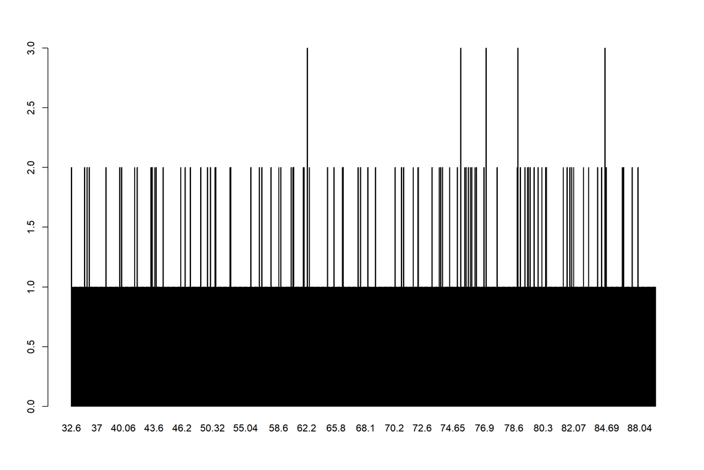

```r
barplot(table(advertising2$time))
```

```r
Gender <- advertising2$gender
Gender_frequency<- table(Gender)
Gender_frequency
```

```
## Gender
##   0   1
## 519 481
```

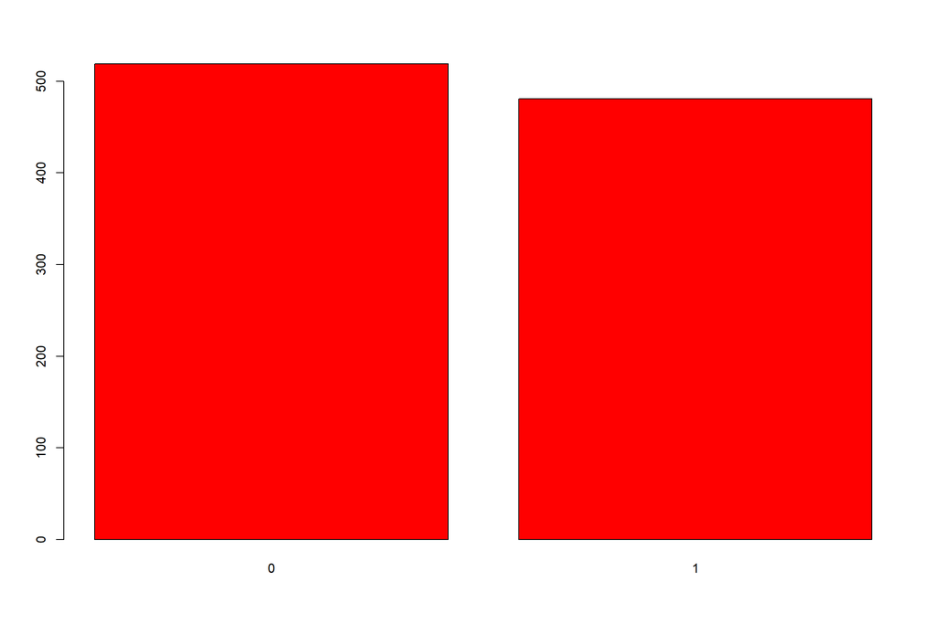

```r
barplot(Gender_frequency,col="Red")
```

```r
Clicked <- advertising2$clicked
Clicked_frequency<- table(Clicked)
Clicked_frequency
```

```
## Clicked
##   0   1
## 500 500
```

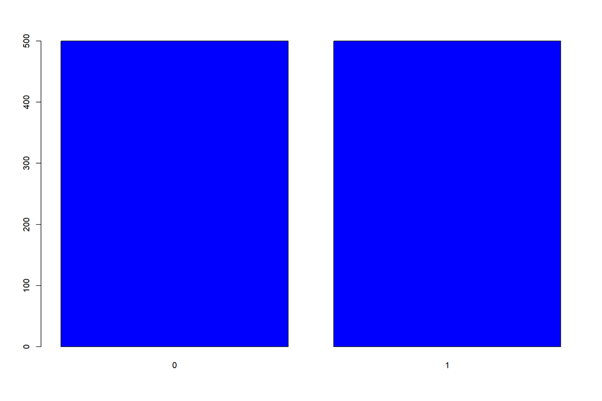

```r
barplot(Clicked_frequency,col="Blue")
```

```r
boxplot.stats(advertising2$time)
```

```
## $stats
## [1] 32.600 51.340 68.215 78.555 91.430
##
## $n
## [1] 1000
##
## $conf
## [1] 66.85523 69.57477
##
## $out
## numeric(0)
```

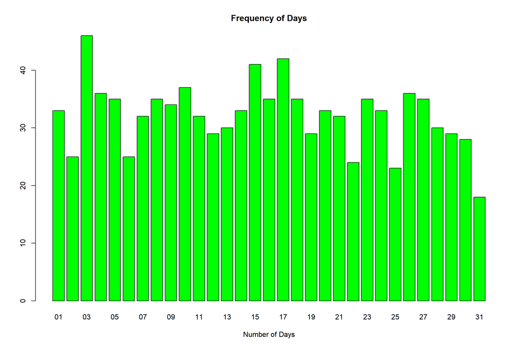

```r
counts <- table(advertising2$day)
  barplot(counts, main="Frequency of Days",  xlab="Number of Days",col="green")
```

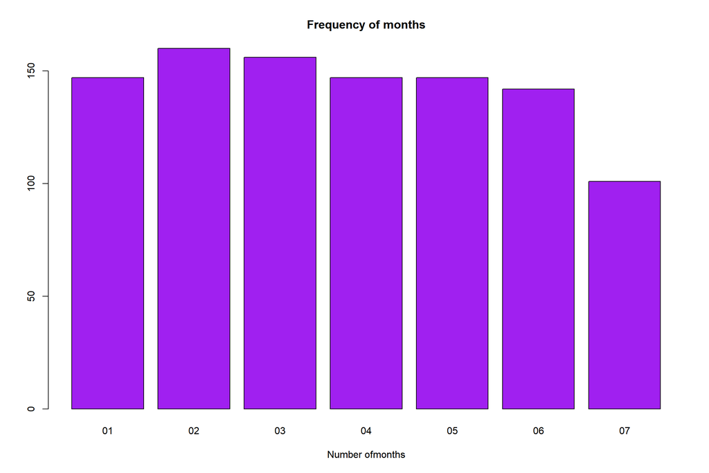

```r
counts <- table(advertising2$month)
  barplot(counts, main="Frequency of months",  xlab="Number ofmonths",col="purple")
```

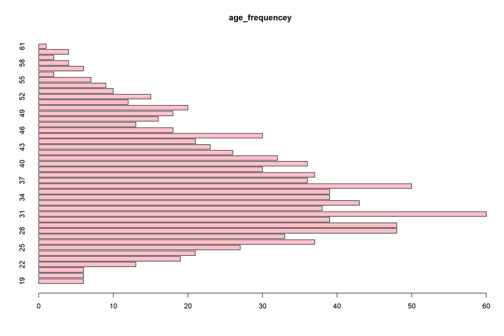

```r
barplot(table(advertising2$Age), horiz=TRUE, main="age_frequencey",col="pink")
```

[figure not shown]

```r
boxplot(rt(100, 5), main="Boxplot")
```

[figure not shown]

```r
stripchart(sample(1:20, 10, replace=TRUE), method="stack", main="Stripchart")
```

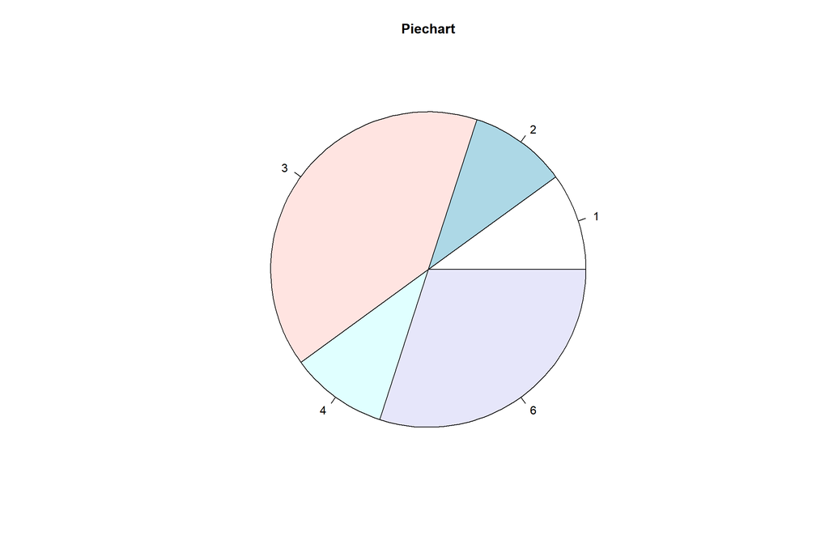

```r
pie(table(sample(1:6, 10, replace=TRUE)), main="Piechart")
```

```r
screen(1)
```

```
## [1] FALSE
```

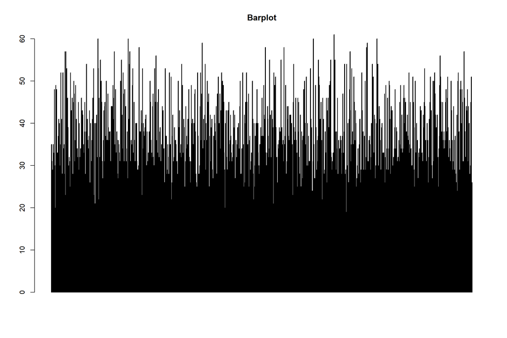

```r
barplot(advertising2$Age, main="Barplot")
```

```r
screen(2)
```

```
## [1] FALSE
```

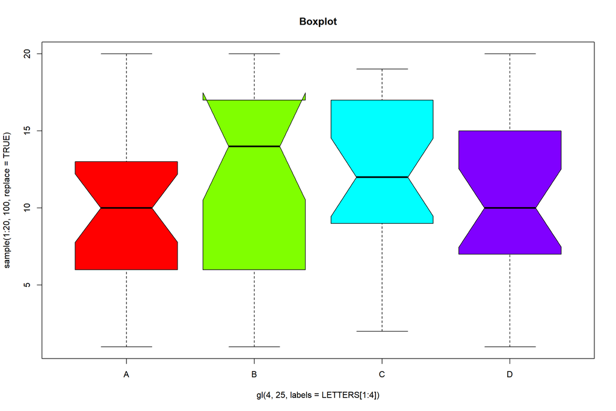

```r
boxplot(sample(1:20, 100, replace=TRUE) ~ gl(4, 25, labels=LETTERS[1:4]),
        col=rainbow(4), notch=TRUE, main="Boxplot")
```

```r
screen(3)
```

```
## [1] FALSE
```

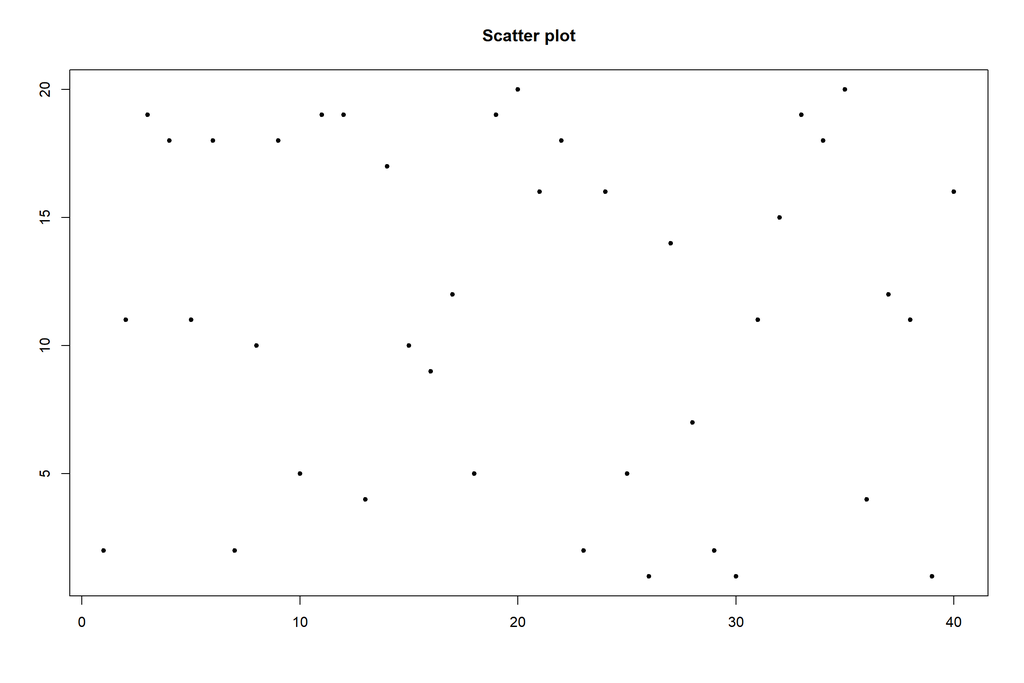

```r
plot(sample(1:20, 40, replace=TRUE), pch=20, xlab=NA, ylab=NA,
     main="Scatter plot")
```

```r
close.screen(all.screens=TRUE)
```

```
## [1] FALSE
```

# 10.Bivariate Analysis

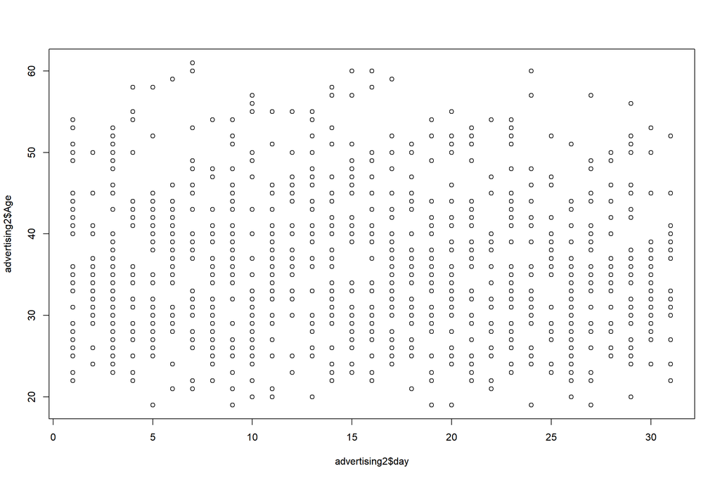

```r
plot(x = advertising2$day, y = advertising2$Age)
```

```r
library("ggplot2")
 #
geom_line()
```

```
## geom_line: na.rm = FALSE, orientation = NA
## stat_identity: na.rm = FALSE
## position_identity
```

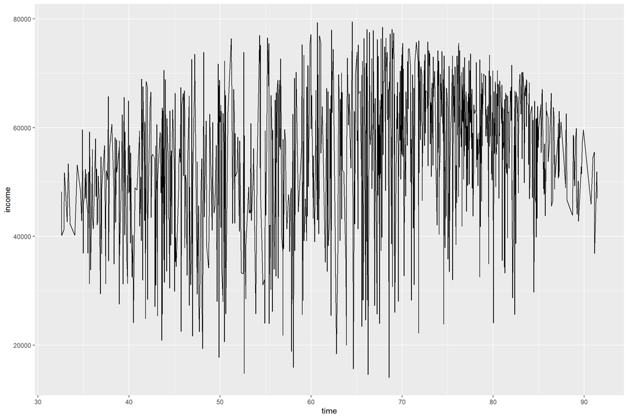

```r
ggplot(data =advertising2,aes(x=time,y=income))+
  geom_line()
```

```r
library(knitr)
library(data.table)
library(tidyverse)
```

```r
#install.packages("corrplot")
```

### 10a.Compute correlation matrix

```r
# function rcorr() [in Hmisc package] is used to compute the significance levels ##for pearson and spearman correlations. It returns both the correlation #coefficients and the p-value of the correlation for all possible pairs of columns #in the data table.

#install.packages("Hmisc")
```

```r
#correlations
res <- cor(advertising2[0:4])
round(res, 2)
```

```
##         time   Age income usage
## time    1.00 -0.33   0.31  0.52
## Age    -0.33  1.00  -0.18 -0.37
## income  0.31 -0.18   1.00  0.34
## usage   0.52 -0.37   0.34  1.00
```

### 10b.correlations between varaiables

```r
#Correlation matrix with significance levels (p-value)
#library("Hmisc")
#rcorr(advertising2[0:4], type = c("pearson","spearman"))
```

```r
#res2 <- rcorr(as.matrix(advertising2[0:4]))
#res2
```

```r
# Extract the correlation coefficients
#res2$r
# Extract p-values
#res2$P
```

```r
# flattenCorrMatrix
# cormat : matrix of the correlation coefficients
# pmat : matrix of the correlation p-values
flattenCorrMatrix <- function(cormat, pmat) {
  ut <- upper.tri(cormat)
  data.frame(
    row = rownames(cormat)[row(cormat)[ut]],
    column = rownames(cormat)[col(cormat)[ut]],
    cor  =(cormat)[ut],
    p = pmat[ut]
    )
}
```

```r
#res2<-rcorr(as.matrix(advertising[,0:4]))
#flattenCorrMatrix(res2$r, res2$P)
```

```r
 #visualizecorrelation matrix
#The R function symnum() replaces correlation coefficients by symbols according to the level of the correlation. It takes the correlation matrix as an argument
symnum(res, abbr.colnames = FALSE)
```

```
##        time Age income usage
## time   1
## Age    .    1
## income .        1
## usage  .    .   .      1
## attr(,"legend")
## [1] 0 ' ' 0.3 '.' 0.6 ',' 0.8 '+' 0.9 '*' 0.95 'B' 1
```

```r
#install.packages("corrplot")#plotting visually enhanced corr matrix
```

.

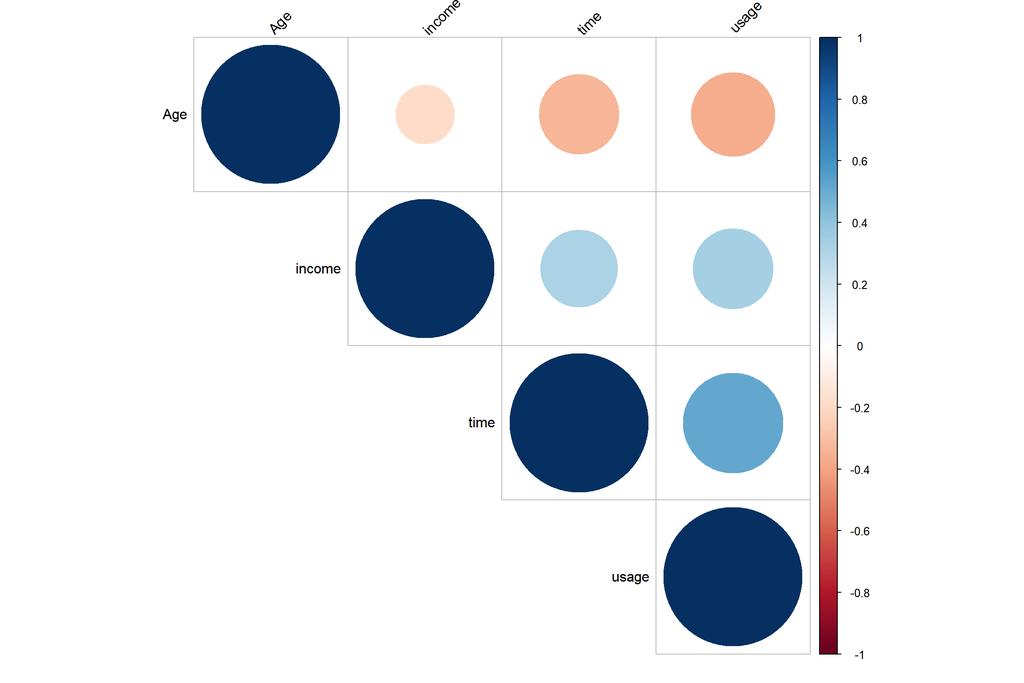

```r
#Positive correlations are displayed in blue and negative correlations in red #color. Color intensity and the size of the circle are proportional to the #correlation coefficients. In the right side of the correlogram, the legend color #shows the correlation coefficients and the corresponding colors
library(corrplot)
corrplot(res, type = "upper", order = "hclust",
         tl.col = "black", tl.srt = 45)
```

### 10c.multivariate Analysis (heatmaps)

```r
#The function chart.Correlation()[ in the package PerformanceAnalytics],is used to display a chart of a correlation matrix.
#install.packages("PerformanceAnalytics")
```

```r
library("PerformanceAnalytics")
```

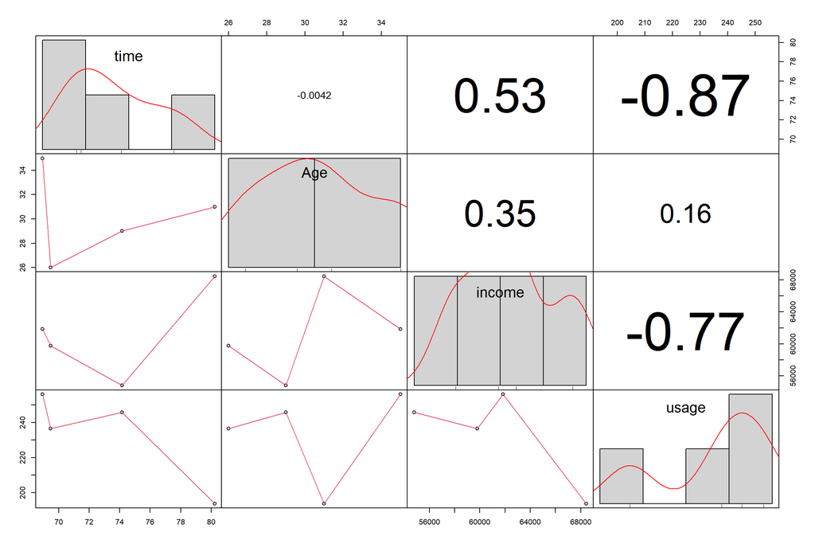

```r
my_data <- advertising[0:4, c(0,1,2,3,4)]
chart.Correlation(my_data, histogram=TRUE, pch=19)
```

heatmap() x : the correlation matrix to be plotted col : color palettes symm : logical indicating if x should be treated symmetrically; can only be true when x is a square matrix.

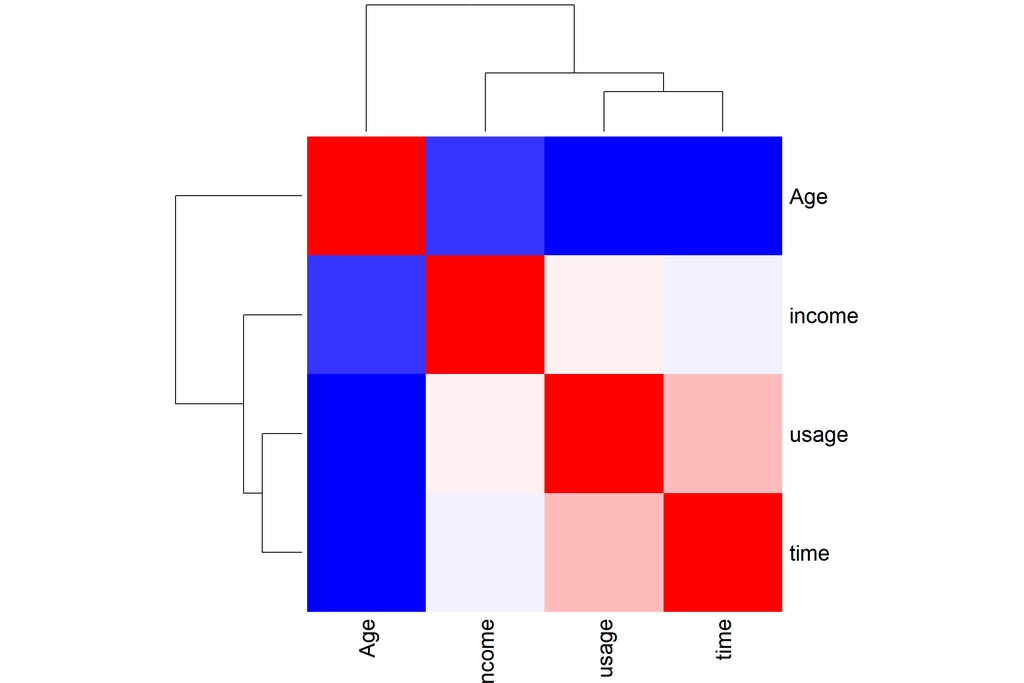

```r
# Get some colors
col<- colorRampPalette(c("blue", "white", "red"))(20)
heatmap(x = res, col = col, symm = TRUE)
```

```r
#gcorrplot can be installed from CRAN as follow:
#install.packages("ggcorrplot")
```

```r
library(ggcorrplot)
```

```r
# Compute a correlation matrix
corr <- round(cor((advertising2[0:3])),1)
corr
```

```
##        time  Age income
## time    1.0 -0.3    0.3
## Age    -0.3  1.0   -0.2
## income  0.3 -0.2    1.0
```

```r
# Compute a matrix of correlation p-values
p.mat <- cor_pmat(advertising2[0:3])
head(p.mat[, 1:3])
```

```
##                time          Age       income
## time   0.000000e+00 4.446423e-27 7.371227e-24
## Age    4.446423e-27 0.000000e+00 6.019232e-09
## income 7.371227e-24 6.019232e-09 0.000000e+00
```

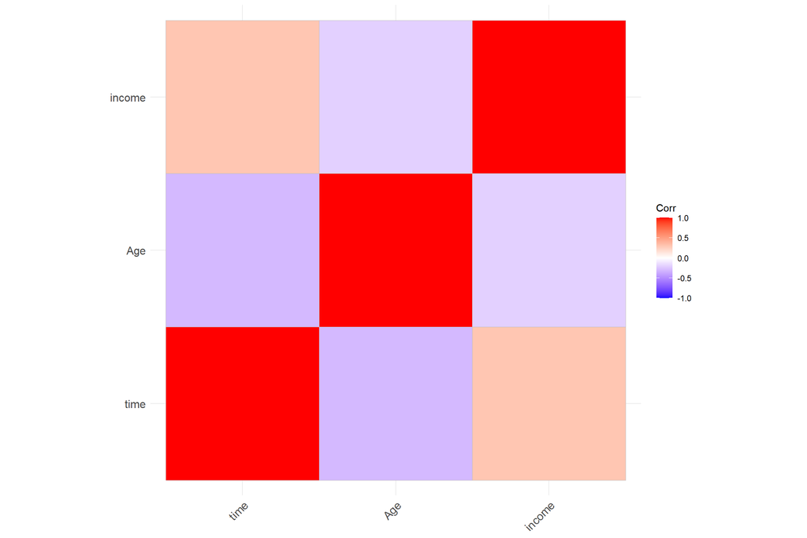

```r
# Visualize the correlation matrix
# --------------------------------
# method = "square" (default)
ggcorrplot(corr)
```

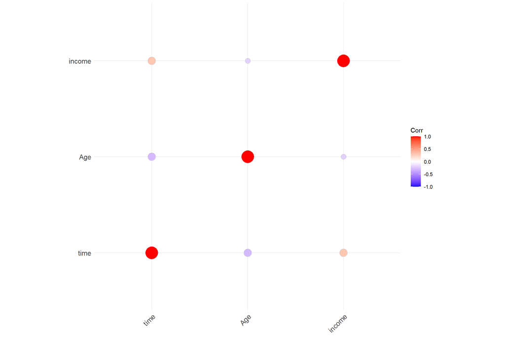

```r
# method = "circle"
ggcorrplot(corr, method = "circle")
```

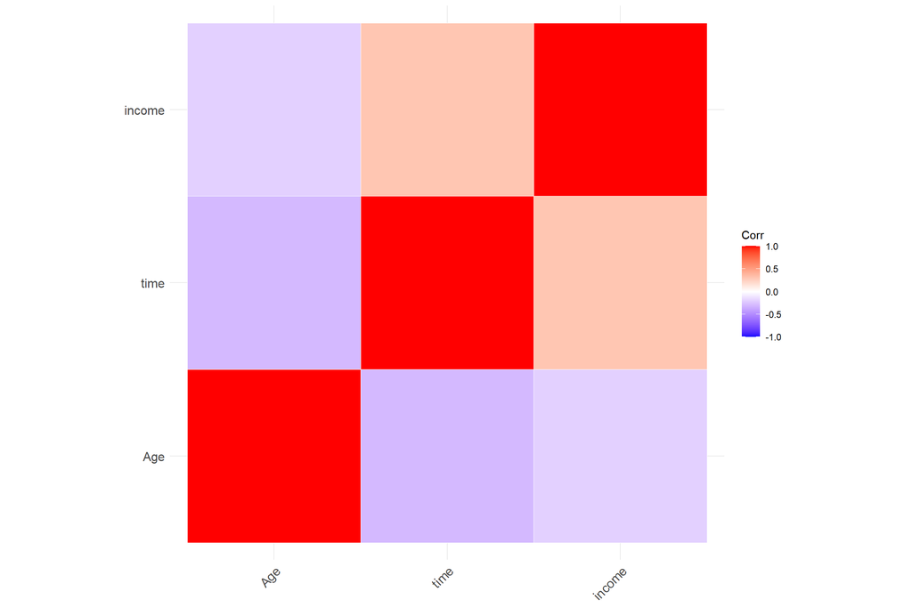

```r
# Reordering the correlation matrix
# --------------------------------
# using hierarchical clustering
ggcorrplot(corr, hc.order = TRUE, outline.col = "white")
```

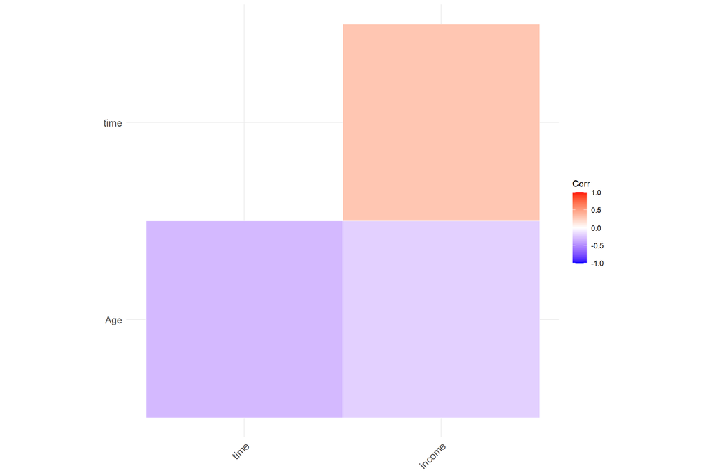

```r
# Types of correlogram layout
# --------------------------------
# Get the lower triangle
ggcorrplot(corr, hc.order = TRUE, type = "lower",
     outline.col = "white")
```

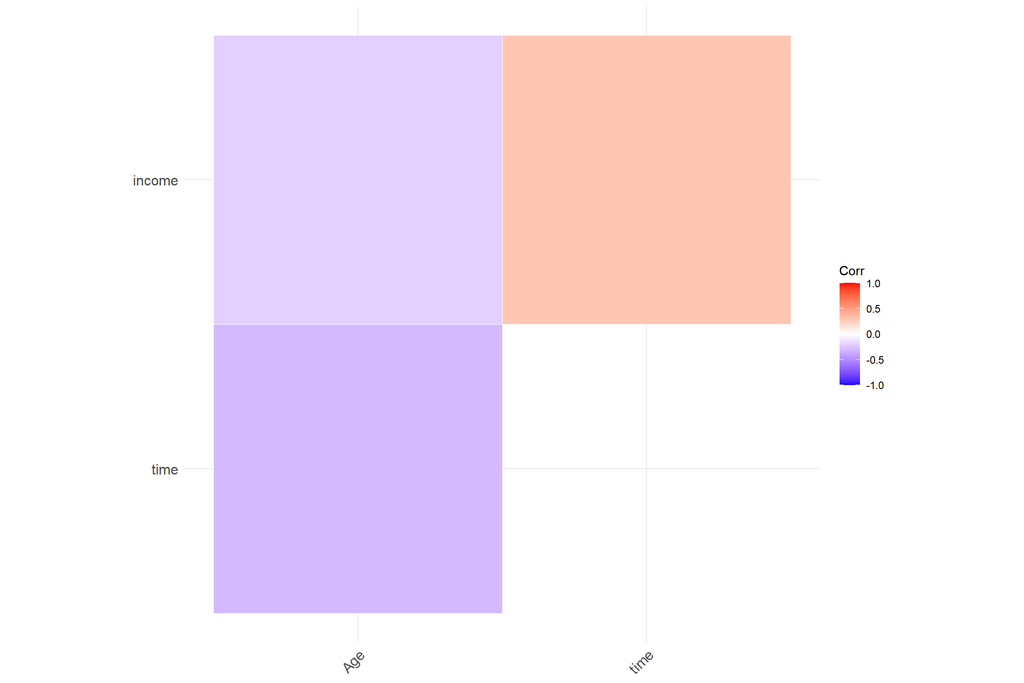

```r
# Get the upeper triangle
ggcorrplot(corr, hc.order = TRUE, type = "upper",
     outline.col = "white")
```

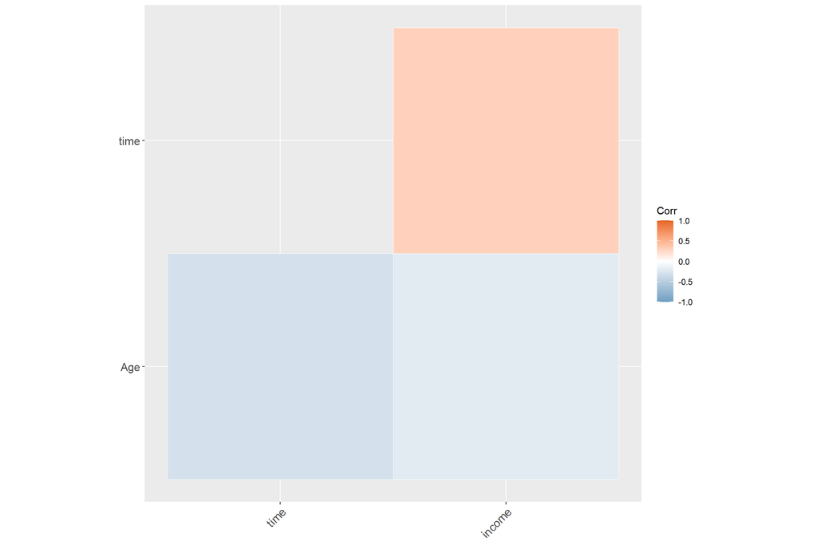

```r
# Change colors and theme
# --------------------------------
# Argument colors
ggcorrplot(corr, hc.order = TRUE, type = "lower",
   outline.col = "white",
   ggtheme = ggplot2::theme_gray,
   colors = c("#6D9EC1", "white", "#E46726"))
```

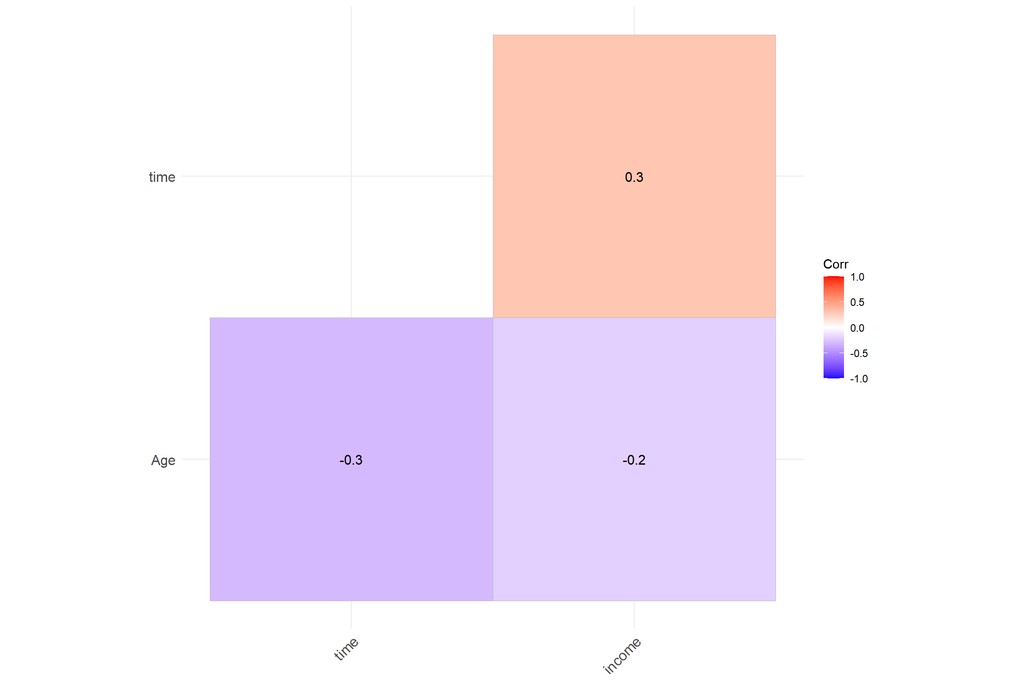

```r
# Add correlation coefficients
# --------------------------------
# argument lab = TRUE
ggcorrplot(corr, hc.order = TRUE, type = "lower",
   lab = TRUE)
```

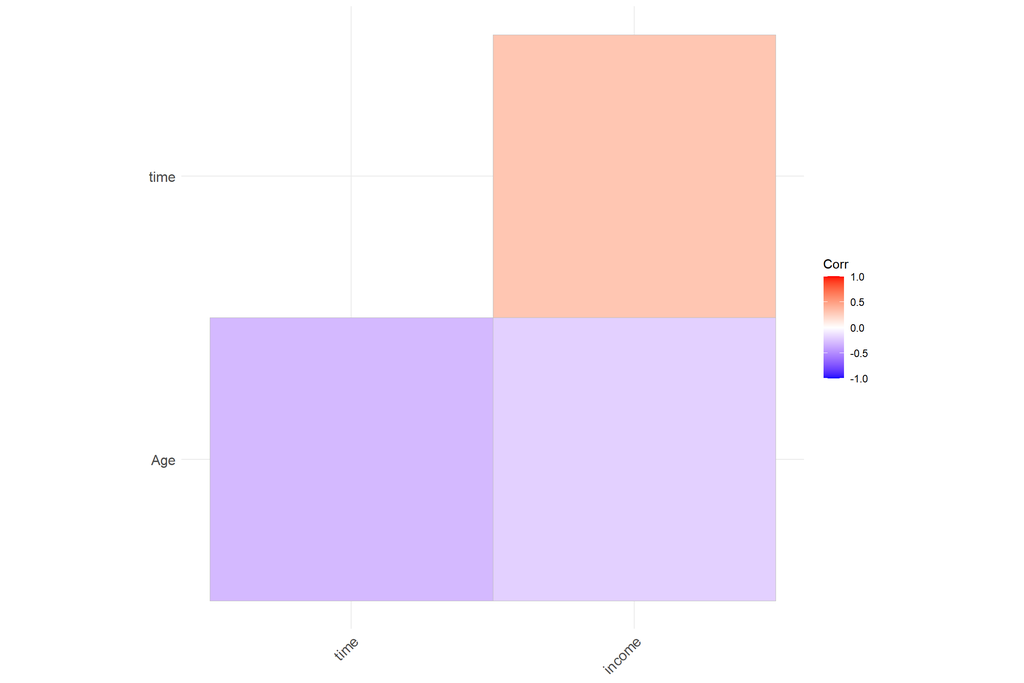

```r
# Add correlation significance level
# --------------------------------
# Argument p.mat
ggcorrplot(corr, hc.order = TRUE,
    type = "lower", p.mat = p.mat)
```

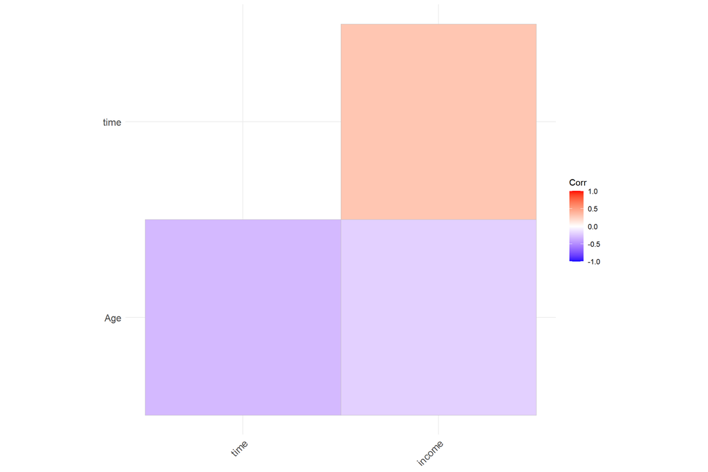

```r
# Leave blank on no significant coefficient
ggcorrplot(corr, p.mat = p.mat, hc.order = TRUE,
    type = "lower", insig = "blank")
```

# 11.Observations

The data was clean and complete i.e. contained no outliers and no missing values.

The modal age was 31 years and the range was between 19 and 61.

The Average Area Income of the individuals was 55,000 which ranged between 13,996.5 and 79,484.80

The Daily Internet Usage had an average of 180 Mbs and ranged between 104.78 and 269.96

The most frequent cities were; Lake Faith and West Ryan

The most frequent Countries were; Fiji and Chad.

The number of females was more than that of male counterparts.

The number of individuals who clicked on the advert and those who didn’t were equal at 500.

There were positive Correlations between the following variables:

- 1.Age and Clicking on the advert**
- 2.gender and Daily Internet Usage
- 3.gender and Income
- 4.Daily Time Spent on Site and Daily Internet Usage.
- 5.Income and Daily Time Spent on Site
- 6.Income and Daily Internet Usage
- 7.Income and gender
- 8.Age and Clicking on the Advert.

# 12. Conclusuion